# Introducción a los análisis estadísticos en R

# Capítulo 7. Correlaciones y regresión lineal

## Correlación lineal

Obtener una correlación en R resulta muy sencillo gracias a la función `cor`. De hecho, con la misma función se pueden conseguir los coeficientes de correlación de Pearson, Spearman y Kendall a través del argumento `method`. Por defecto devuelve el coeficiente de Pearson.

Por ejemplo, vamos a obtener la correlación entre la edad y el coste de la póliza médica. Como ambas variables son cuantitativas, conseguiremos el coeficiente de Pearson. La función `cor.test`, además de darnos el coeficiente de correlación también devuelve un p-valor asociado a este.

```r
coste <- insurance$charges
edad <- insurance$age
cor.test(coste, edad)
```

```
##
##  Pearson's product-moment correlation
##
## data:  coste and edad
## t = 11.453, df = 1336, p-value < 2.2e-16
## alternative hypothesis: true correlation is not equal to 0
## 95 percent confidence interval:
##  0.2494139 0.3470381
## sample estimates:
##       cor
## 0.2990082
```

El coeficiente de correlación alcanzado es de 0.30, lo que implica una asociación moderada entre ambas variables. Existe, por lo tanto, una cierta relación entre la edad de una persona y el coste de su póliza, pero no es demasiado grande, por lo que debe de haber otros factores que determinen el coste. Además, la correlación es significativa, ya que el p-valor asociado es prácticamente 0.

Por otra parte, buscaremos el coeficiente de correlación entre la edad de las personas y su número de hijos. Ambas son variables cuantitativas, pero `children` no tiene una distribución normal, por lo que se obtendrá el coeficiente de Spearman. Las variables que tienen pocos valores diferentes, como el número de hijos, suelen ser no normales.

```r
cor(insurance$age, insurance$children, method = "spearman")
```

```
## [1] 0.05699222
```

En este caso, la relación que existe entre la edad y el número de hijos es prácticamente nula. Como se ve en el siguiente gráfico, la edad mediana es muy similar independientemente del número de hijos.

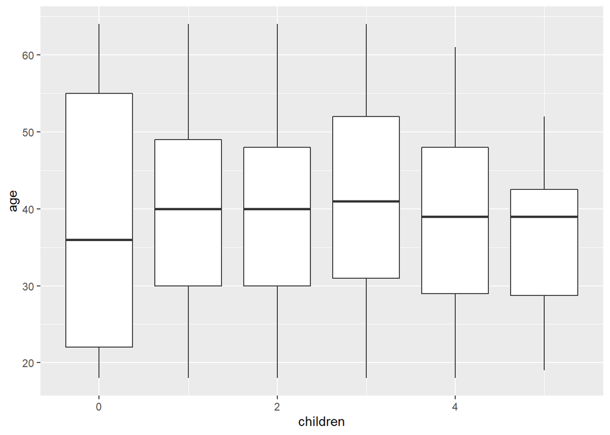

```r
ggplot(insurance, aes(x = children, y = age, group = children))+
     geom_boxplot()
```

En lugar de ir estudiando de manera individual cada posible par de variables, se puede realizar el análisis a todas de manera simultánea, generando una matriz de correlaciones. Obtener esta matriz es, generalmente, uno de los primeros pasos del análisis exploratorio de datos. Es importante que seleccionemos para elaborarla únicamente las variables que sean numéricas.

```r
cor <- cor(insurance[, c("age", "bmi", "children", "charges","SittingHours")])
cor
```

```
##                      age        bmi    children    charges SittingHours
## age           1.00000000 0.10927188  0.04246900 0.29900819  -0.01572802
## bmi           0.10927188 1.00000000  0.01275890 0.19834097   0.03474487
## children      0.04246900 0.01275890  1.00000000 0.06799823  -0.01809964
## charges       0.29900819 0.19834097  0.06799823 1.00000000   0.01669132
## SittingHours -0.01572802 0.03474487 -0.01809964 0.01669132   1.00000000
```

Con la matriz de correlación se puede ver, por ejemplo, que las variables más correlacionadas con el coste de la póliza son la edad y el IMC.

Existe una librería (`corrplot`) especializada en dibujar matrices de correlación, lo que puede ser de mucha utilidad a la hora de presentar los resultados de una forma más visual. Tiene una gran cantidad de parámetros modificables para obtener el gráfico que más se ajuste a nuestras necesidades.

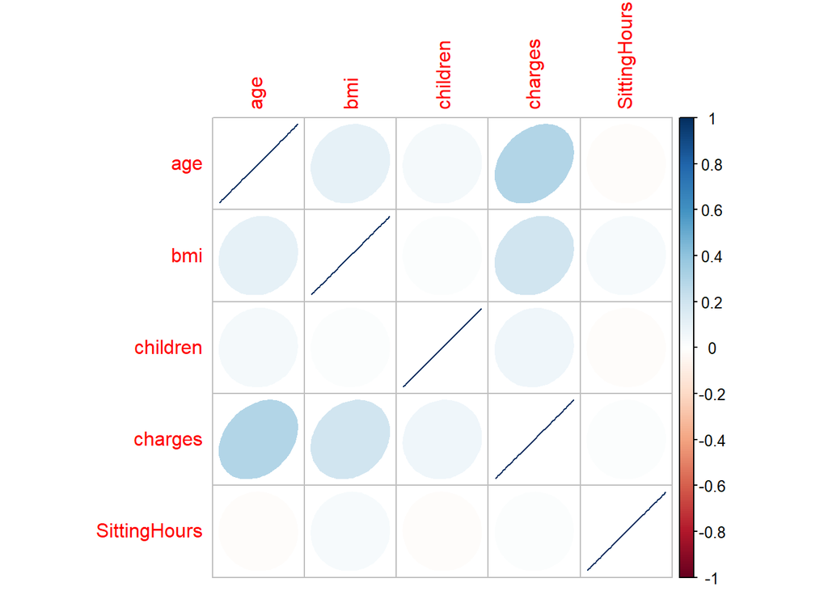

```r
library(corrplot)
corrplot(cor, method = "ellipse")
```

Se puede dibujar de manera simultánea, junto con la matriz de correlación, una matriz de significatividad de estas correlaciones, para poder centrarse en las que sean verdaderamente importantes. Esta acción se lleva a cabo fácilmente con las funciones `ggcorrplot` y `cor_pmat` de la librería `ggcorrplot`, como alternativa a la vista anteriormente. La función `cor_pmat` calcula la significatividad de las correlaciones, si le pasamos nuevamente el conjunto de datos, solo con las variables de las que hayamos calculado la correlación previamente. Aparecerá tachada con una x aquellas correlaciones que no son significativas.

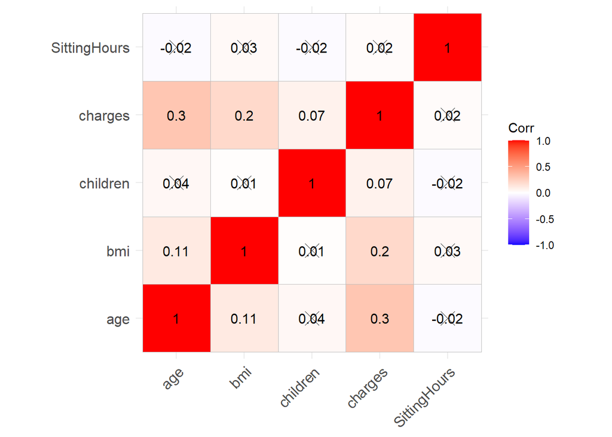

```r
library(ggcorrplot)
p.mat <- cor_pmat(insurance[, c("age", "bmi", "children", "charges", "SittingHours")])
ggcorrplot(cor, lab = T, p.mat = p.mat)
```

## Regresión lineal simple

Llevaremos a cabo un ejemplo completo de creación de un modelo de regresión simple, realizando todas las comprobaciones necesarias expuestas en las secciones anteriores. Vamos a ajustar un modelo que estime el coste de la póliza médica de acuerdo al IMC de las personas.

Como primer paso, estudiamos si existe una relación lineal entre ambas variables.

```r
coste <- insurance$charges
imc <- insurance$bmi
cor.test(coste, imc)
```

```
##
##  Pearson's product-moment correlation
##
## data:  coste and imc
## t = 7.3966, df = 1336, p-value = 2.459e-13
## alternative hypothesis: true correlation is not equal to 0
## 95 percent confidence interval:
##  0.1463052 0.2492822
## sample estimates:
##      cor
## 0.198341
```

Se puede ver que, aunque la correlación entre ambas variables no sea muy alta, sí existe una relación lineal, como indica un p-valor tan pequeño. Procedemos, por lo tanto, a estimar el modelo y estudiar los coeficientes resultantes.

```r
mod <- lm(charges ~ bmi, data = insurance)
summary(mod)
```

```
##
## Call:
## lm(formula = charges ~ bmi, data = insurance)
##
## Residuals:
##    Min     1Q Median     3Q    Max
## -20956  -8118  -3757   4722  49442
##
## Coefficients:
##             Estimate Std. Error t value Pr(>|t|)
## (Intercept)  1192.94    1664.80   0.717    0.474
## bmi           393.87      53.25   7.397 2.46e-13 ***
## ---
## Signif. codes:  0 '***' 0.001 '**' 0.01 '*' 0.05 '.' 0.1 ' ' 1
##
## Residual standard error: 11870 on 1336 degrees of freedom
## Multiple R-squared:  0.03934,    Adjusted R-squared:  0.03862
## F-statistic: 54.71 on 1 and 1336 DF,  p-value: 2.459e-13
```

Comprobamos que el modelo construido resulta significativo a nivel global ($p-valor < 0.001$). Sin embargo, tiene un $R^2$ ajustado muy bajo, de 0.04, lo cual indica que solo el 4% de la variabilidad en el coste de las pólizas está explicado por el IMC de las personas.

El intervalo de confianza de los parámetros lo podemos obtener con la siguiente instrucción. Esta nos devuelve un rango de valores donde, con el 95% de probabilidad, se encontrará la cantidad real de dólares en que se incrementará la póliza por cada unidad de IMC que aumente el individuo.

```r
confint(mod)
```

```
##                  2.5 %    97.5 %
## (Intercept) -2072.9743 4458.8487
## bmi           289.4089  498.3372
```

La ecuación del modelo obtenido que permite estimar el coste de la póliza atendiendo únicamente al IMC se expresa a continuación. Se puede decir que el coste medio de la póliza es de 1192.9$, y que por cada unidad que se incremente el IMC del sujeto, su póliza aumentará de media 393.9$: $\hat{charges` = 1192.94 + 393.87*bmi$

Sin embargo, antes de considerar este modelo como válido para realizar estimaciones, es necesario efectuar un análisis de los residuos para comprobar que cumple el resto de requisitos.

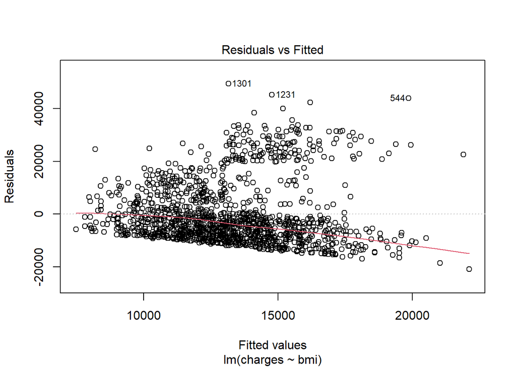

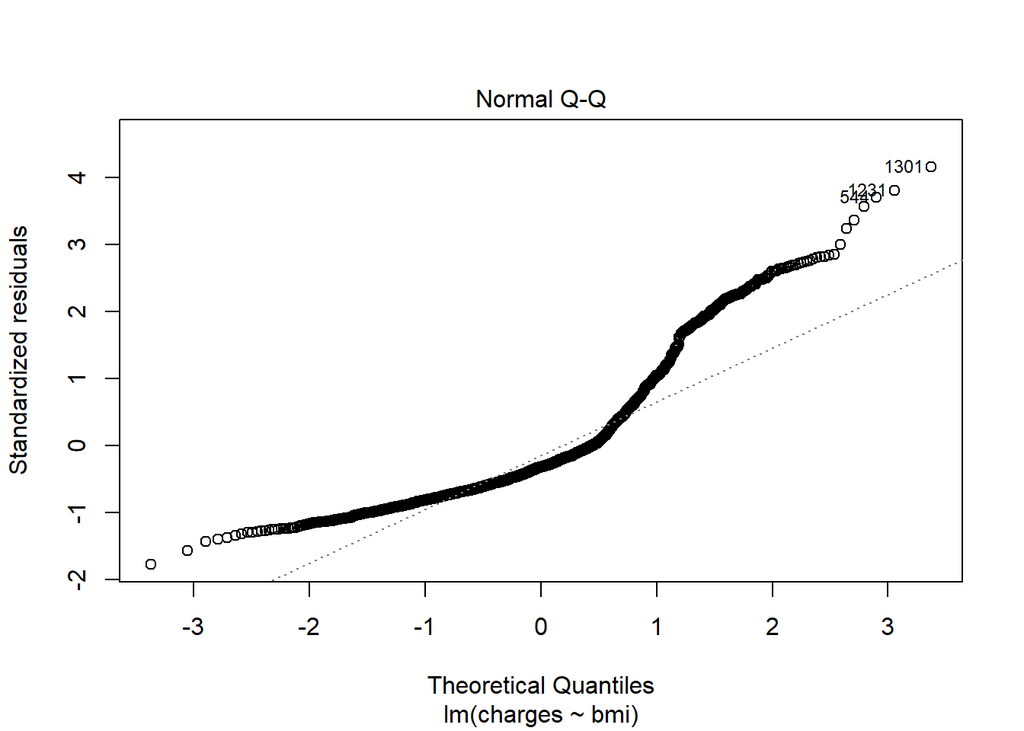

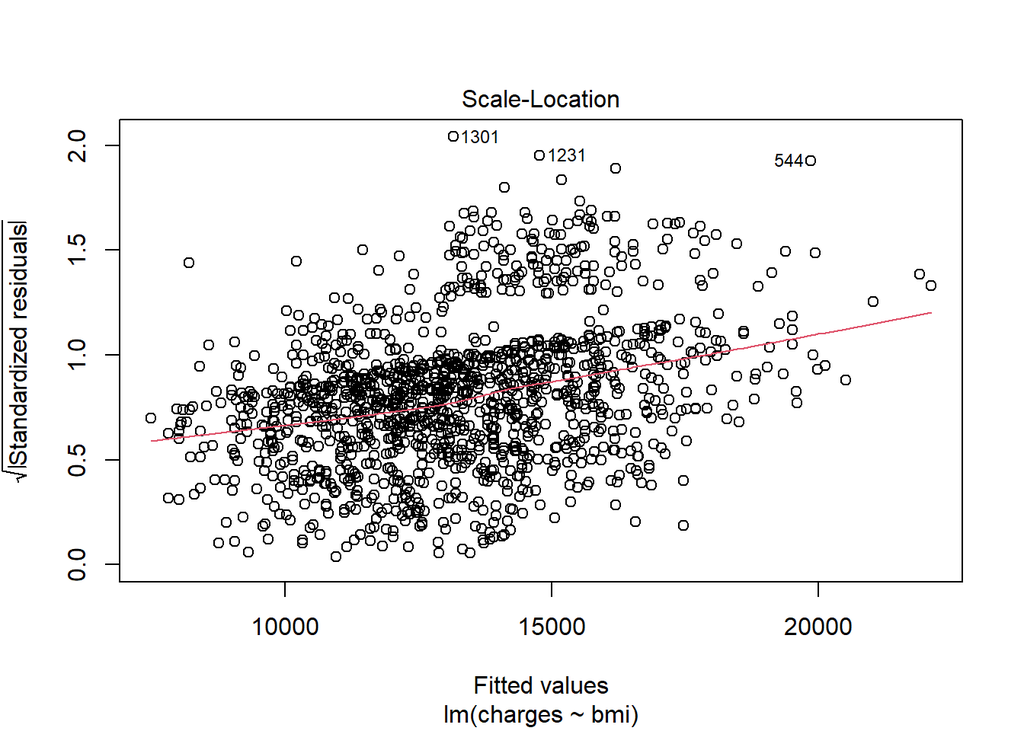

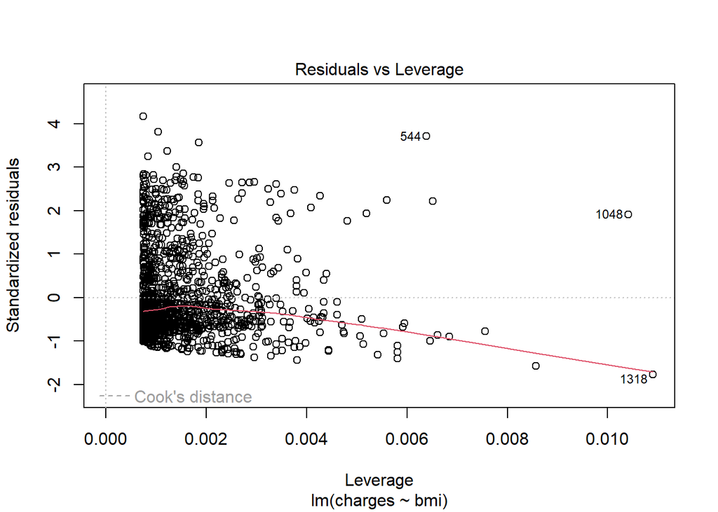

```r
plot(mod)
```

A la izquierda se muestran los residuos por cada valor estimado y se puede apreciar cómo estos residuos, es decir, los errores del modelo, no son iguales cuando estima valores pequeños de coste que cuando son valores grandes. Esta circunstancia nos indica que la varianza de los residuos puede ser no homocedástica. Además, atendiendo a la segunda figura, la distribución de los residuos no es demasiado lineal. Para asegurarnos, vamos a realizar un test de normalidad a los residuos del modelo.

```r
shapiro.test(mod$residuals)
```

```
##
##  Shapiro-Wilk normality test
##
## data:  mod$residuals
## W = 0.86198, p-value < 2.2e-16
```

Los datos evidencian que se descarta la hipótesis nula de normalidad de los residuos, por lo que, tal y como se había intuido de los residuos, no se cumplen los requisitos para considerar válido este modelo.

## Regresión lineal múltiple

Vamos a efectuar un ejemplo completo de creación de un modelo de regresión múltiple, realizando todas las comprobaciones necesarias expuestas en las secciones anteriores. Ajustaremos un modelo que estime el beneficio de una startup de acuerdo con sus gastos en investigación, administración y marketing. Para ello, utilizaremos el dataset `50_Startups`, disponible en https://www.kaggle.com/farhanmd29/50-startups, que incluye esta información de 50 startups de diferentes estados de Estados Unidos. A continuación vemos un breve resumen del mismo.

```r
startups <- read.csv("50_Startups.csv")
head(startups)
```

| R.D.Spend | Administration | Marketing.Spend | State | Profit |
| --- | --- | --- | --- | --- |
| 165349.2 | 136897.80 | 471784.1 | New York | 192261.8 |
| 162597.7 | 151377.59 | 443898.5 | California | 191792.1 |
| 153441.5 | 101145.55 | 407934.5 | Florida | 191050.4 |
| 144372.4 | 118671.85 | 383199.6 | New York | 182902.0 |
| 142107.3 | 91391.77 | 366168.4 | Florida | 166187.9 |
| 131876.9 | 99814.71 | 362861.4 | New York | 156991.1 |

Como primer paso, estudiaremos la presencia de multicolinealidad. Con este fin obtendremos la matriz de correlación de las variables `R.D.Spend`,`Administration` y `Marketing.Spend`.

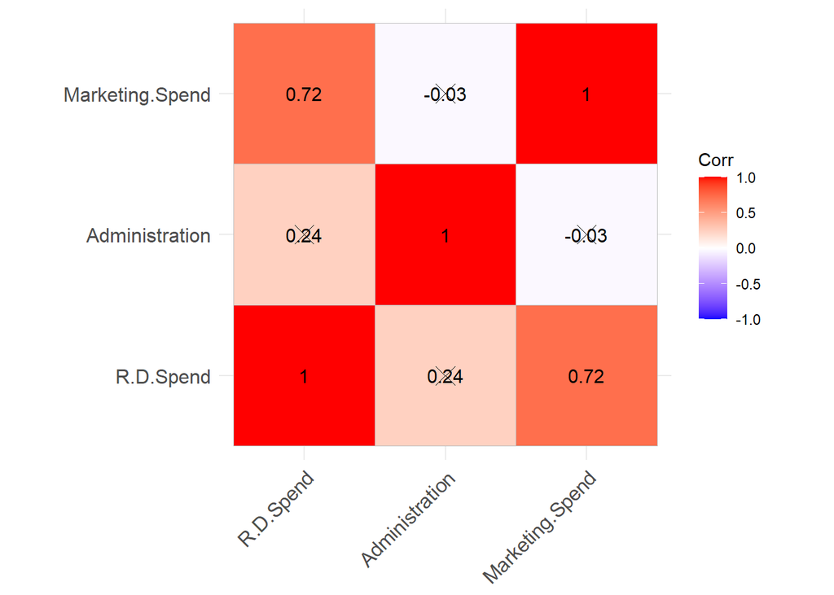

```r
library(ggcorrplot)
data = startups[,c("R.D.Spend", "Administration", "Marketing.Spend")]
ggcorrplot(cor(data), p.mat = cor_pmat(data), lab = TRUE)
```

```r
mod <- lm(Profit ~ R.D.Spend + Administration + Marketing.Spend, data = startups)
car::vif(mod)
```

```
##       R.D.Spend  Administration Marketing.Spend
##        2.468903        1.175091        2.326773
```

Los coeficientes del VIF se encuentran entre 1 y 2.5 por lo que, a pesar de la correlación alta entre dos de las variables, concluimos que no supone un problema de multicolinealidad. Procedemos, por tanto, a estudiar los coeficientes resultantes del modelo.

```r
summary(mod)
```

```
##
## Call:
## lm(formula = Profit ~ R.D.Spend + Administration + Marketing.Spend,
##     data = startups)
##
## Residuals:
##    Min     1Q Median     3Q    Max
## -33534  -4795     63   6606  17275
##
## Coefficients:
##                   Estimate Std. Error t value Pr(>|t|)
## (Intercept)      5.012e+04  6.572e+03   7.626 1.06e-09 ***
## R.D.Spend        8.057e-01  4.515e-02  17.846  < 2e-16 ***
## Administration  -2.682e-02  5.103e-02  -0.526    0.602
## Marketing.Spend  2.723e-02  1.645e-02   1.655    0.105
## ---
## Signif. codes:  0 '***' 0.001 '**' 0.01 '*' 0.05 '.' 0.1 ' ' 1
##
## Residual standard error: 9232 on 46 degrees of freedom
## Multiple R-squared:  0.9507, Adjusted R-squared:  0.9475
## F-statistic:   296 on 3 and 46 DF,  p-value: < 2.2e-16
```

Vemos que el modelo construido resulta significativo a nivel global ($p-valor < 0.001$). Además, tiene un $R^2$ ajustado de 0.95, un valor bastante alto que indica que el 95% de la variabilidad en el beneficio de las startups está explicado por las variables introducidas en el modelo. Sin embargo, apreciamos que hay dos variables incluidas (`Administration` y `Marketing.Spend`) que no resultan significativas, por lo que si quisiéramos construir el modelo más óptimo habría que excluirlas y volver a calcular el modelo sin ellas. En ese caso, estaríamos ante un modelo lineal simple. Sin embargo, se mantiene el análisis posterior como ejemplo de estudio de una regresión lineal múltiple.

Como medida de la robustez del modelo, elaboramos los intervalos de confianza de los coeficientes. Se puede observar que coinciden las variables cuyo intervalo de confianza incluye el cero con aquellas con el parámetro no significativo.

```r
confint(mod)
```

```
##                         2.5 %       97.5 %
## (Intercept)      3.689273e+04 6.335165e+04
## R.D.Spend        7.148383e-01 8.965918e-01
## Administration  -1.295316e-01 7.589964e-02
## Marketing.Spend -5.886553e-03 6.034268e-02
```

A continuación, realizaremos el estudio de los residuos del modelo.

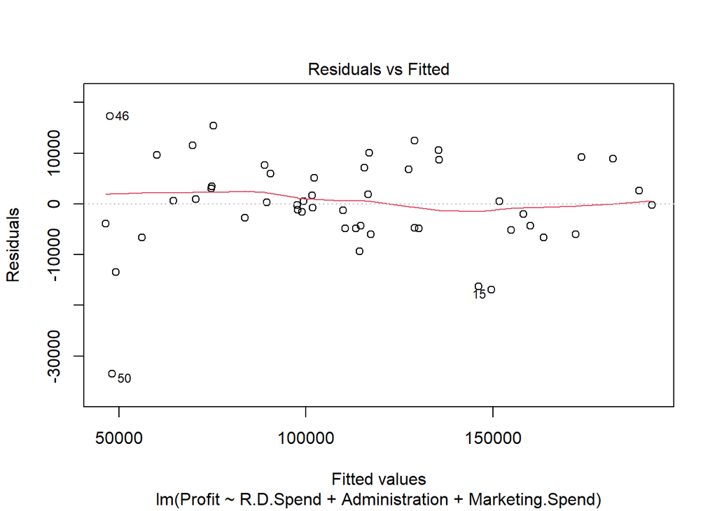

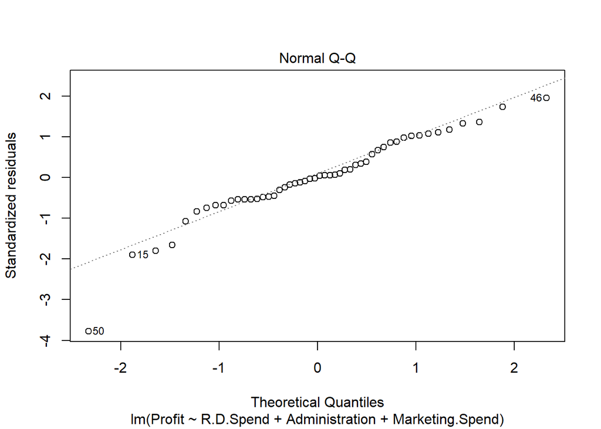

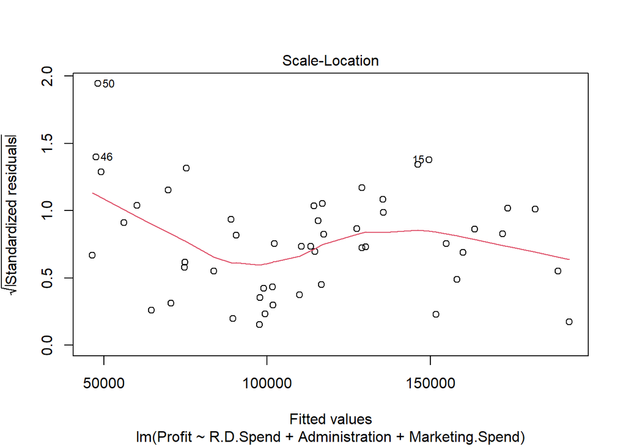

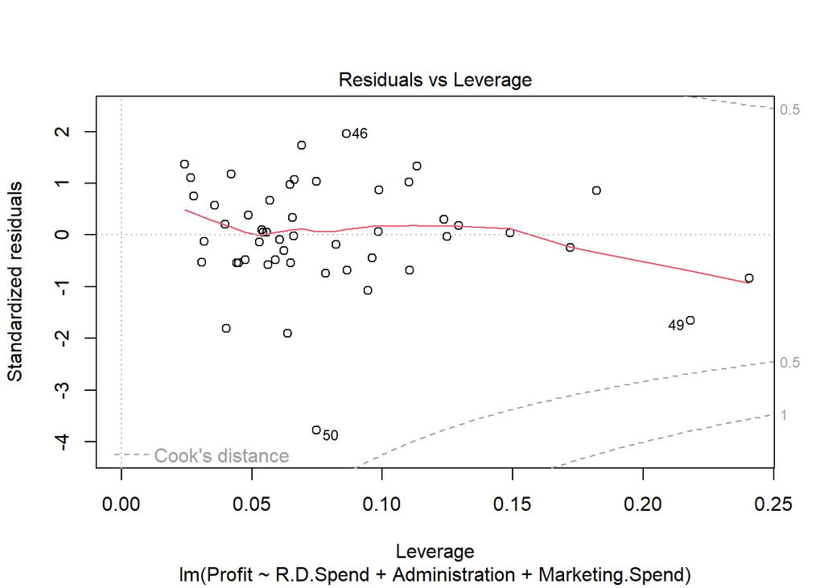

```r
plot(mod)
```

Vemos en la segunda figura de la fila superior que la distribución es prácticamente lineal, por lo que se cumple el requisito de normalidad y homocedasticidad de los residuos. Además, como se observa en la figura de la segunda fila, no hay valores extremos, ya que la distancia de Cook de ninguna muestra supera los 0.3.

Finalmente, ahora que ya hemos construido un modelo válido, podemos utilizarlo para realizar estimaciones sobre el beneficio de nuestra startup. Por ejemplo, supongamos que hacemos un gasto en investigación de 105.000$, otro en marketing de 70000$ y un tercero en administración de 75.000$. El beneficio estimado sería de 134.617$, con un intervalo de confianza de 95% [124434, 144800]$.

```r
datosEjemplo = data.frame(R.D.Spend = 105000, Marketing.Spend = 70000, Administration = 75000)
predict(mod, datosEjemplo, interval = "confidence")
```

```
##      fit    lwr    upr
## 1 134617 124434 144800
```

### Inclusión de variables categóricas

Como ejemplo de la manera en que lo trata R, se incluye el modelo que estima el coste de la póliza de acuerdo a si el sujeto es mujer u hombre, y su edad. A la hora de definir qué categoria de la variable toma el valor 0 y cuál el valor 1, si no se le fuerza de alguna manera, R lo hace siguiendo el orden alfabético.

```r
mod <- lm(charges ~ age + sex, data = insurance)
summary(mod)
```

```
##
## Call:
## lm(formula = charges ~ age + sex, data = insurance)
##
## Residuals:
##    Min     1Q Median     3Q    Max
##  -8821  -6947  -5511   5443  48203
##
## Coefficients:
##             Estimate Std. Error t value Pr(>|t|)
## (Intercept)  2343.62     994.35   2.357   0.0186 *
## age           258.87      22.47  11.523   <2e-16 ***
## sexmale      1538.83     631.08   2.438   0.0149 *
## ---
## Signif. codes:  0 '***' 0.001 '**' 0.01 '*' 0.05 '.' 0.1 ' ' 1
##
## Residual standard error: 11540 on 1335 degrees of freedom
## Multiple R-squared:  0.09344,    Adjusted R-squared:  0.09209
## F-statistic:  68.8 on 2 and 1335 DF,  p-value: < 2.2e-16
```

Si la variable categórica tiene más de dos clases, es necesario generar tantas variables *dummy* como categorías menos 1. Por ejemplo, se incluye el modelo que estima el coste de la póliza de acuerdo con la edad y la región en la que reside el individuo:

```r
mod <- lm(charges ~ age + region, data = insurance)
summary(mod)
```

```
##
## Call:
## lm(formula = charges ~ age + region, data = insurance)
##
## Residuals:
##    Min     1Q Median     3Q    Max
##  -9594  -6471  -5497   4802  47303
##
## Coefficients:
##                 Estimate Std. Error t value Pr(>|t|)
## (Intercept)      3252.69    1089.33   2.986  0.00288 **
## age               258.57      22.44  11.523  < 2e-16 ***
## regionnorthwest  -970.30     904.98  -1.072  0.28384
## regionsoutheast  1414.09     880.48   1.606  0.10850
## regionsouthwest -1107.77     904.99  -1.224  0.22115
## ---
## Signif. codes:  0 '***' 0.001 '**' 0.01 '*' 0.05 '.' 0.1 ' ' 1
##
## Residual standard error: 11530 on 1333 degrees of freedom
## Multiple R-squared:  0.09661,    Adjusted R-squared:  0.0939
## F-statistic: 35.64 on 4 and 1333 DF,  p-value: < 2.2e-16
```

### Interacciones entre variables

En R, podemos incluir una interacción entre variables introduciéndolas unidas por el símbolo `*` en la fórmula. Además, es importante considerar que en el momento en que incorporamos la interacción de dos variables, también se incluye cada una de las variables por separado en el modelo. Por ejemplo, la estimación del coste de las pólizas considerando la edad, el sexo, el ser fumador y la interacción de las dos últimas. El insertar la interacción entre estas dos variables tiene sentido si pensamos que no es igual que una mujer sea fumadora que lo sea un hombre, es decir, el efecto que provoca en el coste que una persona sea fumador es diferente a si es un hombre o una mujer.

```r
 mod <- lm(charges ~ age + sex*smoker, data = insurance)
summary(mod)
```

```
##
## Call:
## lm(formula = charges ~ age + sex * smoker, data = insurance)
##
## Residuals:
##      Min       1Q   Median       3Q      Max
## -17098.7  -2004.0  -1331.4   -337.2  29981.8
##
## Coefficients:
##                   Estimate Std. Error t value Pr(>|t|)
## (Intercept)       -2138.91     563.14  -3.798 0.000152 ***
## age                 274.65      12.42  22.122  < 2e-16 ***
## sexmale            -502.30     391.10  -1.284 0.199258
## smokeryes         22213.97     654.11  33.961  < 2e-16 ***
## sexmale:smokeryes  2909.84     872.88   3.334 0.000881 ***
## ---
## Signif. codes:  0 '***' 0.001 '**' 0.01 '*' 0.05 '.' 0.1 ' ' 1
##
## Residual standard error: 6375 on 1333 degrees of freedom
## Multiple R-squared:  0.7237, Adjusted R-squared:  0.7229
## F-statistic: 872.9 on 4 and 1333 DF,  p-value: < 2.2e-16
```

Como vemos en el resumen del modelo, para estimar el coste de la póliza es significativo la edad de la persona, el que sea fumador y la interacción de ser fumador con su sexo. Sin embargo, el sexo por sí solo no es significativo. Por otro lado, como la interacción entre fumador y sexo es significativa, efectivamente el coste para una persona que sea fumador es diferente a si es un hombre fumador o una mujer fumadora. En particular, ser fumador aumenta el coste en 22213$, pero si eres hombre fumador se incrementa 2909$ más. La ecuación resultante sería: $\hat{Coste` = -2138.91 + 274.65 * Edad + 22213.97 * SerFumador - 502.30 * SerHombre + 2909.84 * SerHombreFumador$.

### Regresión polinómica

Para ejemplificar el uso de las regresiones polinómicas, trabajaremos con el conjunto de datos `Boston`, que contiene 14 variables sobre 506 propiedades en Boston, como contaminación, criminalidad de la zona, número de habitaciones, ratio profesor-alumno, información socioeconómica y valor de las propiedades. Vamos a generar dos modelos, uno que estime el valor de la propiedad (`medv`, en miles de dolares) solo considerando el porcentaje de población de la zona que se encuentra en una situación socioecónomica baja (`lstat`), y otro considerando este término al cuadrado. Para incorporar los términos polinómicos los incluimos en la fórmula dentro de la función `I()`, como se puede ver en el ejemplo.

```r
data("Boston", package = "MASS")
modLineal <- lm(medv ~ lstat, data = Boston)
summary(modLineal)
```

```
##
## Call:
## lm(formula = medv ~ lstat, data = Boston)
##
## Residuals:
##     Min      1Q  Median      3Q     Max
## -15.168  -3.990  -1.318   2.034  24.500
##
## Coefficients:
##             Estimate Std. Error t value Pr(>|t|)
## (Intercept) 34.55384    0.56263   61.41   <2e-16 ***
## lstat       -0.95005    0.03873  -24.53   <2e-16 ***
## ---
## Signif. codes:  0 '***' 0.001 '**' 0.01 '*' 0.05 '.' 0.1 ' ' 1
##
## Residual standard error: 6.216 on 504 degrees of freedom
## Multiple R-squared:  0.5441, Adjusted R-squared:  0.5432
## F-statistic: 601.6 on 1 and 504 DF,  p-value: < 2.2e-16
```

La ecuación ajustada del modelo es $\hat{Valor` = 34.55 - 0.95 * Porcentaje_{modesto}$. Es decir, a más población modesta desde el punto de vista socioeconómico, menor será el valor del inmueble.

```r
modCuadratico <- lm(medv ~ lstat + I(lstat^2), data = Boston)
summary(modCuadratico)
```

```
##
## Call:
## lm(formula = medv ~ lstat + I(lstat^2), data = Boston)
##
## Residuals:
##      Min       1Q   Median       3Q      Max
## -15.2834  -3.8313  -0.5295   2.3095  25.4148
##
## Coefficients:
##              Estimate Std. Error t value Pr(>|t|)
## (Intercept) 42.862007   0.872084   49.15   <2e-16 ***
## lstat       -2.332821   0.123803  -18.84   <2e-16 ***
## I(lstat^2)   0.043547   0.003745   11.63   <2e-16 ***
## ---
## Signif. codes:  0 '***' 0.001 '**' 0.01 '*' 0.05 '.' 0.1 ' ' 1
##
## Residual standard error: 5.524 on 503 degrees of freedom
## Multiple R-squared:  0.6407, Adjusted R-squared:  0.6393
## F-statistic: 448.5 on 2 and 503 DF,  p-value: < 2.2e-16
```

La ecuación ajustada del nuevo modelo es: $\hat{Valor` = 42.86 -2.33 * Porcentaje_{modesto` + 0.04 * Porcentaje_{modesto}^2$

Para comprender mejor las diferencias entre ambos modelos, vamos a hacer estimaciones de manera gráfica. Para ello, dibujaremos los valores reales, los estimados por la ecuación ajustada del modelo lineal y los estimados por la ecuación ajustada por el modelo cuadrático.

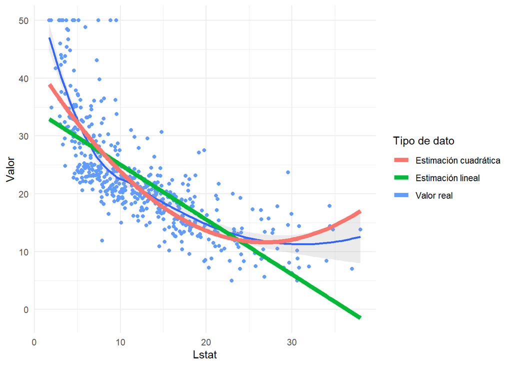

```r
# Obtenemos las estimaciones
dataLstat = data.frame(lstat = Boston$lstat)
estimacionLineal <- predict(modLineal, dataLstat)
estimacionCuadratica <- predict(modCuadratico, dataLstat)

# Creamos un data.frame con la información necesaria para generar el gráfico

Valor <- data.frame(Lstat = Boston$lstat, Valor = Boston$medv,  EstimacionLineal = estimacionLineal, EstimacionCuadratica = estimacionCuadratica)

# Hacemos el gráfico

ggplot(Valor, aes(x = Lstat, y = Valor))+
  geom_point(aes(col = "Valor real"))+
  geom_smooth(alpha = 0.2)+
  geom_line(data = Valor, aes(x = Lstat, y = estimacionLineal, col = "Estimación lineal"), lwd = 2)+
  geom_line(data = Valor, aes(x = Lstat, y = estimacionCuadratica, col = "Estimación cuadrática"), lwd = 2)+
  labs(col = "Tipo de dato")+
  theme_minimal()
```

La selección de características será la que optimice el *Akaike Information Criterion* (AIC) del modelo. El AIC es una métrica que permite comparar modelos similares al $R^2_{ajustado}$, ya que tiene en cuenta cómo de bien estima la variable dependiente el modelo y el número de variables independientes que utiliza.

En el caso hacia atrás, como se ve a continuación, nos informa de que el modelo empieza con un AIC de 920.87. El primer paso es suprimir la variable `State`, que es la que menos AIC aporta. En el siguiente el modelo tiene 916.88 de AIC, y se elimina `Administration`, con menos AIC en ese momento. El modelo final contiene únicamente las variables de gasto en investigación (`R.D.Spend`) y en marketing (`Marketing.Spend`).

```r
library(MASS)
modeloCompleto <- lm(Profit ~., data = startups)
step.model <- stepAIC(modeloCompleto, direction = "backward", trace = T)
```

```
## Start:  AIC=920.87
## Profit ~ R.D.Spend + Administration + Marketing.Spend + State
##
##                   Df  Sum of Sq        RSS     AIC
## - State            2 5.1666e+05 3.9209e+09  916.88
## - Administration   1 2.3816e+07 3.9442e+09  919.17
## <none>                          3.9203e+09  920.87
## - Marketing.Spend  1 2.2071e+08 4.1410e+09  921.61
## - R.D.Spend        1 2.6878e+10 3.0799e+10 1021.94
##
## Step:  AIC=916.88
## Profit ~ R.D.Spend + Administration + Marketing.Spend
##
##                   Df  Sum of Sq        RSS     AIC
## - Administration   1 2.3539e+07 3.9444e+09  915.18
## <none>                          3.9209e+09  916.88
## - Marketing.Spend  1 2.3349e+08 4.1543e+09  917.77
## - R.D.Spend        1 2.7147e+10 3.1068e+10 1018.37
##
## Step:  AIC=915.18
## Profit ~ R.D.Spend + Marketing.Spend
##
##                   Df  Sum of Sq        RSS     AIC
## <none>                          3.9444e+09  915.18
## - Marketing.Spend  1 3.1165e+08 4.2560e+09  916.98
## - R.D.Spend        1 3.1149e+10 3.5094e+10 1022.46
```

En el proceso hacia delante, hemos de crear un modelo vacío e indicarle cuál es el rango de posibilidades que tiene en el argumento `scope`. Le señalamos que la opción más simple es el mismo modelo vacío y que la más completa considere todas las variables que mencionamos. La selección en este caso comienza con un AIC de 1061.42, y en una primera acción incorpora la variable `R.D.Spend`, que es la que más empequeñece el AIC. En un siguiente paso se añade `Marketing.Spend`, la única que queda que empequeñece el AIC. Aquí se detiene la selección.

```r
modeloVacio <- lm(Profit ~ 1, data = startups)
step.model <- stepAIC(modeloVacio, direction = "forward",
                scope=list(lower = modeloVacio, upper = ~R.D.Spend + Administration + Marketing.Spend + State), trace = T)
```

```
## Start:  AIC=1061.42
## Profit ~ 1
##
##                   Df  Sum of Sq        RSS     AIC
## + R.D.Spend        1 7.5349e+10 4.2560e+09  916.98
## + Marketing.Spend  1 4.4511e+10 3.5094e+10 1022.46
## + Administration   1 3.2071e+09 7.6398e+10 1061.36
## <none>                          7.9605e+10 1061.42
## + State            2 1.9006e+09 7.7704e+10 1064.21
##
## Step:  AIC=916.98
## Profit ~ R.D.Spend
##
##                   Df Sum of Sq        RSS    AIC
## + Marketing.Spend  1 311651716 3944394850 915.18
## <none>                         4256046566 916.98
## + Administration   1 101704903 4154341663 917.77
## + State            2  14451679 4241594888 920.81
##
## Step:  AIC=915.18
## Profit ~ R.D.Spend + Marketing.Spend
##
##                  Df Sum of Sq        RSS    AIC
## <none>                        3944394850 915.18
## + Administration  1  23538549 3920856301 916.88
## + State           2    239050 3944155801 919.17
```

En esta ocasión, ambas direcciones nos han dado el mismo resultado, pero podría ocurrir en modelos con muchas variables que las conclusiones fueran diferentes. Si en la función `stepAIC()` indicamos como dirección *both*, devuelve directamente la mejor solución considerando ambas direcciones.

### Validación y test

- **Bootstrap** El bootstrap nos permite obtener una mejor estimación tanto de los valores de los coeficientes del modelo como de lo bueno que es el modelo resultante. Lo primero se lleva a cabo con la función `boot()` de la librería `boot`, a la cual se le pasa el conjunto de datos, el modelo y la cantidad de remuestras que se quieren considerar. En este ejemplo, realizaremos 100 remuestras.

```r
library(boot)
model_coef <- function(data, index){
    coef(lm(Profit ~., data = startups, subset = index))
}
boot(startups, model_coef, 100)
```

```
##
## ORDINARY NONPARAMETRIC BOOTSTRAP
##
##
## Call:
## boot(data = startups, statistic = model_coef, R = 100)
##
##
## Bootstrap Statistics :
##          original        bias     std. error
## t1*  5.012534e+04 -3.557503e+02 5.993669e+03
## t2*  8.060231e-01 -9.645009e-03 4.708824e-02
## t3* -2.700432e-02  4.654979e-03 4.393287e-02
## t4*  2.697986e-02  1.981137e-03 1.536830e-02
## t5*  1.987888e+02 -1.223848e+02 3.211165e+03
## t6* -4.188702e+01  1.536872e+02 3.966867e+03
```

`boot()` reporta la estimación de los coeficientes obtenida por *bootstrap*, siendo t1 el intercepto ($\beta_0$), t2 el gasto en investigación ($\beta_1$) y t3 el gasto en administración ($\beta_2$), de acuerdo al orden de las variables en el conjunto de datos ($\beta_n$). Como se puede apreciar, son muy similares a los obtenidos por el modelo hecho con todos los datos, que se exponen a continuación, pero los alcanzados por *bootstrap* han sido calculados considerando la variabilidad muestral, por lo que son más fiables.

```r
 summary(lm(Profit ~., data = startups))
```

```
##
## Call:
## lm(formula = Profit ~ ., data = startups)
##
## Residuals:
##    Min     1Q Median     3Q    Max
## -33504  -4736     90   6672  17338
##
## Coefficients:
##                   Estimate Std. Error t value Pr(>|t|)
## (Intercept)      5.013e+04  6.885e+03   7.281 4.44e-09 ***
## R.D.Spend        8.060e-01  4.641e-02  17.369  < 2e-16 ***
## Administration  -2.700e-02  5.223e-02  -0.517    0.608
## Marketing.Spend  2.698e-02  1.714e-02   1.574    0.123
## StateFlorida     1.988e+02  3.371e+03   0.059    0.953
## StateNew York   -4.189e+01  3.256e+03  -0.013    0.990
## ---
## Signif. codes:  0 '***' 0.001 '**' 0.01 '*' 0.05 '.' 0.1 ' ' 1
##
## Residual standard error: 9439 on 44 degrees of freedom
## Multiple R-squared:  0.9508, Adjusted R-squared:  0.9452
## F-statistic: 169.9 on 5 and 44 DF,  p-value: < 2.2e-16
```

En cuanto al rendimiento del modelo, también lo podemos calcular considerando *bootstrap*. Para ello es necesaria la librería `caret`, usada de la siguiente manera:

```r
library(caret)
train.control <- trainControl(method = "boot", number = 100)
train(Profit ~., data = startups, method = "lm", trControl = train.control)
```

```
## Linear Regression
##
## 50 samples
##  4 predictor
##
## No pre-processing
## Resampling: Bootstrapped (100 reps)
## Summary of sample sizes: 50, 50, 50, 50, 50, 50, ...
## Resampling results:
##
##   RMSE      Rsquared   MAE
##   10244.17  0.9399189  7910.604
##
## Tuning parameter 'intercept' was held constant at a value of TRUE
```

# Capítulo 8. Detección de valores atípicos y faltantes

## Valores atípicos u *outliers*

### Detección univariante

- **Detección mediante EDA**

Las formas más sencillas de detección de *outliers* nos ayudarán sobre todo a encontrar aquellos que provengan de errores. Al obtener la descripción de la variable, junto con sus mínimos y máximos, o al visualizar su histograma o su boxplot, podremos intuir la presencia de este tipo de valores. Vamos a estudiar la variable IMC (`bmi`), para lo que obtendremos su descripción básica mediante `summary()`, y elaboraremos su histograma y su boxplot.

```r
summary(insurance$bmi)
```

```
##    Min. 1st Qu.  Median    Mean 3rd Qu.    Max.
##   15.96   26.30   30.40   30.66   34.69   53.13
```

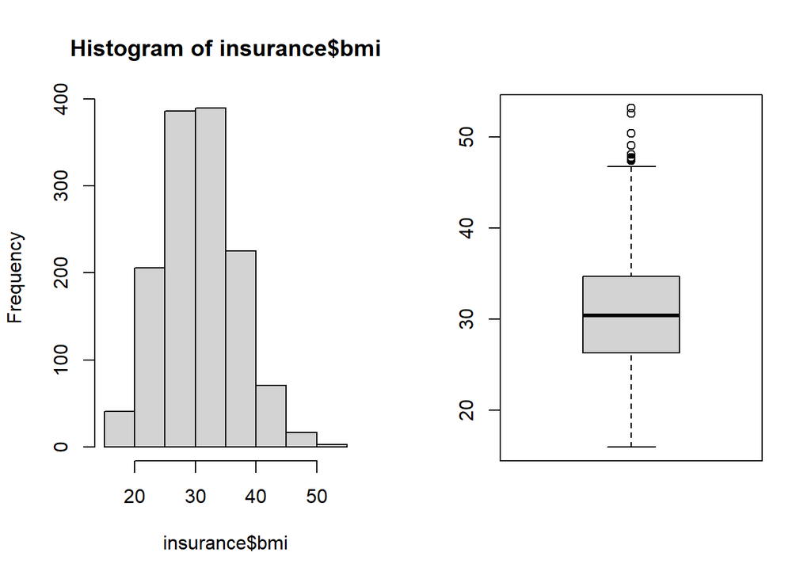

```r
par(mfrow=c(1,2))
hist(insurance$bmi)
boxplot(insurance$bmi)
```

En este caso observamos que hay un salto bastante grande entre el tercer cuartil y el máximo, intuyéndose una cola a la derecha en la distribución. Ello podría deberse a un error en la entrada de datos o a valores extraordinariamente altos. El histograma muestra esa ligera cola a la derecha, y en el boxplot podemos observar unos puntos que se encuentran fuera de los bigotes. Sin embargo, no están tan alejados como para poder deducir simplemente que se trata de errores en la introducción de datos. Al fin y al cabo, un IMC de 53 podría corresponder a una persona que pese unos 145 kilos y mida 1.65 metros, lo cual, aunque improbable, es posible.

De cualquier manera, la utilización del boxplot y la información de los cuartiles es el primer método del que disponemos para detectar outliers potenciales. Con él se puede intuir que serán valores extremos todos aquellos puntos que se encuentren fuera del intervalo $[q_1 - 1.5* IQR, q_3 + 1.5* IQR]$, siendo $q_1$ el primer cuartil, $q_3$ el tercer cuartil e IQR el intervalo intercuartílico, esto es, $q_3 - q_1$. Por ejemplo, en el caso de la variable `bmi`, el intervalo sería [26.3 - 1.5 * 8.4, 34.7 + 1.5 * 8.4], es decir [13.7, 47.3]. Se concluye que el menor valor del intervalo es más bajo que el mínimo de la distribución, por lo que no habrá outliers por la izquierda. Sin embargo, el valor más alto de la distribución es mayor que el máximo del intervalo, por tanto sí los habrá por la derecha, como se puede ver en el boxplot. Mediante las siguientes instrucciones podremos recuperar los valores extremos y el número de fila en nuestro conjunto de datos.

```r
outliersIQR <- boxplot.stats(insurance$bmi)$out
print(sort(outliersIQR))
```

```
## [1] 47.41 47.52 47.60 47.74 48.07 49.06 50.38 52.58 53.13
```

Con la función `which` podemos ver cuáles son los individuos que tienen estos valores extremos.

```r
which(insurance$bmi %in% outliersIQR)
```

```
## [1]  117  287  402  544  848  861 1048 1089 1318
```

Así, parece que tenemos 9 outliers potenciales. Este método de detección es el más sencillo e intuitivo, pero no se recomienda su uso pues resulta demasiado agresivo.

- **Detección mediante tests estadísticos**

El *z-score* es una técnica utilizada para normalizar los datos, devolviéndolos escalados entre -1 y 1, con una media de 0 y desviación típica de 1. Las variables numéricas, una vez tipificadas con el *z-score*, se pueden comparar con una distribución normal para ver cuál es la probabilidad de que cada valor pertenezca a ella o no. Esta acción se puede realizar directamente utilizado la librería `outliers`, mediante su función `scores()`. Es interesante leer la documentación de esta función dada su flexibilidad, para lo que se puede utilizar el comando `help(scores)`. El parámetro `type` sirve para especificar qué tipo de métrica queremos obtener. El parámetro `prob` se emplea para definir el tipo de salida que pretendemos lograr. Si no lo definimos, nos devolverá el `score`, si lo definimos como `TRUE` nos retornará el p-valor obtenido tras comparar los scores con su respectiva distribución de referencia, mientras que si lo definimos como un número entre 0 y 1 nos devolverá un vector lógico, compuesto de TRUE y FALSE, marcando las posiciones cuyos p-valores son mayores que el que se ha introducido. Por ejemplo, si lo definimos como 0.95, nos indicará las posiciones con un p-valor mayor a 0.95, que representarán al 5% de valores más extremos. Si lo definimos como 0.99, nos devolverá el 1% más extremo de los datos.

```r
library(outliers)
Perc5MasExtremo <- scores(insurance$bmi, type = "z", prob = 0.95)
cat(sum(Perc5MasExtremo), "valores pertenecen al 5% más extremo")
```

```
## 129 valores pertenecen al 5% más extremo
```

```r
library(outliers)
Perc1MasExtremo <- scores(insurance$bmi, type = "z", prob = 0.99)
cat(sum(Perc1MasExtremo), "valores pertenecen al 1% más extremo\n")
```

```
## 22 valores pertenecen al 1% más extremo
```

Se observa que el número de valores extremos aumenta considerablemente respecto a los calculados con el método anterior, pero tenemos un método estadístico detrás para reforzar nuestra decisión. Por ejemplo, si decidiéramos excluir a la población cuyo IMC forma parte del 1% más extremo para centrarnos en el 99% de la población restante, estaríamos eliminando los siguientes valores:

```r
data.frame(Index = which(Perc1MasExtremo),
           Value = insurance$bmi[Perc1MasExtremo])%>%arrange(Value)
```

| Index | Value |
| --- | --- |
| 173 | 15.96 |
| 1157 | 44.88 |
| 1025 | 45.32 |
| 583 | 45.43 |
| 293 | 45.54 |
| 1132 | 45.90 |
| 942 | 46.09 |
| 550 | 46.20 |
| 455 | 46.53 |
| 661 | 46.53 |
| 931 | 46.53 |
| 548 | 46.70 |
| 439 | 46.75 |
| 544 | 47.41 |
| 402 | 47.52 |
| 861 | 47.60 |
| 1089 | 47.74 |
| 287 | 48.07 |
| 117 | 49.06 |
| 848 | 50.38 |
| 1048 | 52.58 |
| 1318 | 53.13 |

Apreciamos que una observación es considerada outlier por tener poco IMC, mientras que las otras 21 lo son por tenerlo muy alto.

### Detección multivariante

Para ejemplificarlo estudiemos los valores de `bmi` y `charges` de forma conjunta, de manera que terminemos eliminando a los sujetos cuya diferencia entre ambos valores sea extrema. Por ejemplo, personas con el IMC muy alto que paguen demasiado poco, o viceversa.

Primero, seleccionamos las variables

```r
studyData <- insurance%>%select(bmi, charges)
```

Ahora las normalizamos con el z-score

```r
studyData$bmi <- scores(studyData$bmi, type = "z")
studyData$charges <- scores(studyData$charges, type = "z")
```

Calculamos la distancia de mahalanobis

```r
mahalanobis_distance <- mahalanobis(studyData,
                                    colMeans(studyData),
                                    cov(studyData))
```

Finalmente, detectamos los valores anómalos

```r
outliers <- scores(mahalanobis_distance, type = "z", prob = 0.99)
cat(sum(outliers), "valores pertenecen al 1% más extremo")
```

```
## 54 valores pertenecen al 1% más extremo
```

A continuación, mostramos los primeros 15 casos:

```r
data.frame(Index = which(outliers),
           BMI = insurance$bmi[outliers],
           Charges = insurance$charges[outliers])%>%
    arrange(BMI, Charges)%>%
    head(15)
```

| Index | BMI | Charges |
| --- | --- | --- |
| 129 | 17.765 | 32734.19 |
| 1301 | 30.360 | 62592.87 |
| 1302 | 30.875 | 46718.16 |
| 95 | 31.300 | 47291.06 |
| 678 | 31.350 | 46130.53 |
| 252 | 32.200 | 47305.31 |
| 1147 | 32.800 | 52590.83 |
| 329 | 33.800 | 47928.03 |
| 421 | 33.880 | 46889.26 |
| 1231 | 34.485 | 60021.40 |
| 110 | 35.090 | 47055.53 |
| 820 | 35.530 | 55135.40 |
| 422 | 35.860 | 46599.11 |
| 1285 | 36.300 | 47403.88 |
| 331 | 36.385 | 48517.56 |

Observamos que la mayoría de los outliers detectados tiene costes muy altos (recordamos que la media del coste de la póliza era de 13270$), además de tener el IMC en rango de obesidad, salvo un caso (17.8). Si se analizan el resto de valores, también aparecen observaciones con costes muy bajos.

Finalmente, a la hora de emplear métodos multivariantes es importante manejar variables que tengan relación entre sí en el contexto del que provengan los datos.

## Valores faltantes

### Descripción y visualización

Antes de aplicar las funciones es importante asegurarse de que todos los valores faltantes aparecen, en efecto, como `NA`. Puede suceder, sobre todo si los datos se han recogido manualmente en un éxcel, que estos valores hayan sido incluidos como los responsables de la recogida de datos han considerado oportuno. Algunos ejemplos pueden ser “9999”, “99999”, o simplemente dejar la celda vacía con un espacio ” “. Si descubrimos alguno de estos casos en nuestro dataset, podemos solucionarlo de la siguiente manera. Antes de aplicar las siguientes instrucciones, es importante saber si los valores que vamos a sustituir por `NA` son razonablemente posibles en los datos. Por ejemplo, si se recogen superficies de países, puede ser que”99999” sea un valor correcto.

```r
dataset[dataset == ""] = NA
dataset[dataset == " "] = NA
dataset[dataset == 9999] = NA
dataset[dataset == 99999] = NA
```

A nivel general, `n_miss()` devuelve la cantidad de celdas vacías que hay en el conjunto de datos. Por otra parte, `pct_miss_case()` lo hace con el porcentaje del total.

```r
library(naniar)
n_miss(airquality)
```

```
## [1] 44
```

```r
pct_miss_case(airquality)
```

```
## [1] 27.45098
```

```r
miss_case_summary(airquality)
```

| case | n_miss | pct_miss |
| --- | --- | --- |
| 5 | 2 | 33.33333 |
| 27 | 2 | 33.33333 |
| 6 | 1 | 16.66667 |
| 10 | 1 | 16.66667 |
| 11 | 1 | 16.66667 |
| 25 | 1 | 16.66667 |
| 26 | 1 | 16.66667 |
| 32 | 1 | 16.66667 |
| 33 | 1 | 16.66667 |
| 34 | 1 | 16.66667 |
| 35 | 1 | 16.66667 |
| 36 | 1 | 16.66667 |
| 37 | 1 | 16.66667 |
| 39 | 1 | 16.66667 |
| 42 | 1 | 16.66667 |
| 43 | 1 | 16.66667 |
| 45 | 1 | 16.66667 |
| 46 | 1 | 16.66667 |
| 52 | 1 | 16.66667 |
| 53 | 1 | 16.66667 |
| 54 | 1 | 16.66667 |
| 55 | 1 | 16.66667 |
| 56 | 1 | 16.66667 |
| 57 | 1 | 16.66667 |
| 58 | 1 | 16.66667 |
| 59 | 1 | 16.66667 |
| 60 | 1 | 16.66667 |
| 61 | 1 | 16.66667 |
| 65 | 1 | 16.66667 |
| 72 | 1 | 16.66667 |

[output cut: 123 more lines]

```r
miss_case_table(airquality)
```

| n_miss_in_case | n_cases | pct_cases |
| --- | --- | --- |
| 0 | 111 | 72.54902 |
| 1 | 40 | 26.14379 |
| 2 | 2 | 1.30719 |

Estas dos últimas funciones tienen una versión disponible para describir los valores faltantes en las columnas:

```r
miss_var_summary(airquality)
```

| variable | n_miss | pct_miss |
| --- | --- | --- |
| Ozone | 37 | 24.183007 |
| Solar.R | 7 | 4.575163 |
| Wind | 0 | 0.000000 |
| Temp | 0 | 0.000000 |
| Month | 0 | 0.000000 |
| Day | 0 | 0.000000 |

```r
miss_case_table(airquality)
```

| n_miss_in_case | n_cases | pct_cases |
| --- | --- | --- |
| 0 | 111 | 72.54902 |
| 1 | 40 | 26.14379 |
| 2 | 2 | 1.30719 |

Si estamos interesados en hacer un estudio más pormenorizado de los valores faltantes, podemos combinar estas funciones con otras del paquete `dplyr`, como `group_by()`. Como ejemplo, obtendremos los valores faltantes por mes de seguimiento. Se puede apreciar entonces que la variable `Ozone` está prácticamente vacía durante el mes de junio, en el que se alcanza hasta el 70% de valores faltantes. En septiembre, sin embargo, solamente hay un faltante.

```r
airquality%>% group_by(Month)%>% miss_var_summary()
```

| Month | variable | n_miss | pct_miss |
| --- | --- | --- | --- |
| 5 | Ozone | 5 | 16.129032 |
| 5 | Solar.R | 4 | 12.903226 |
| 5 | Wind | 0 | 0.000000 |
| 5 | Temp | 0 | 0.000000 |
| 5 | Day | 0 | 0.000000 |
| 6 | Ozone | 21 | 70.000000 |
| 6 | Solar.R | 0 | 0.000000 |
| 6 | Wind | 0 | 0.000000 |
| 6 | Temp | 0 | 0.000000 |
| 6 | Day | 0 | 0.000000 |
| 7 | Ozone | 5 | 16.129032 |
| 7 | Solar.R | 0 | 0.000000 |
| 7 | Wind | 0 | 0.000000 |
| 7 | Temp | 0 | 0.000000 |
| 7 | Day | 0 | 0.000000 |
| 8 | Ozone | 5 | 16.129032 |
| 8 | Solar.R | 3 | 9.677419 |
| 8 | Wind | 0 | 0.000000 |
| 8 | Temp | 0 | 0.000000 |
| 8 | Day | 0 | 0.000000 |
| 9 | Ozone | 1 | 3.333333 |
| 9 | Solar.R | 0 | 0.000000 |
| 9 | Wind | 0 | 0.000000 |
| 9 | Temp | 0 | 0.000000 |
| 9 | Day | 0 | 0.000000 |

Esta información también se puede obtener de manera gráfica utilizando funciones del mismo paquete. Por ejemplo, `gg_miss_var()` muestra un lollipop plot, similar a un gráfico de barras horizontal, con el porcentaje de las variables faltantes. Este, como en el último ejemplo, también puede ser estratificado por alguna variable que sea de nuestro interés. Nótese que en la figura estratificada por mes se ha añadido el argumento `show_pct = T`, que muestra los valores en porcentaje.

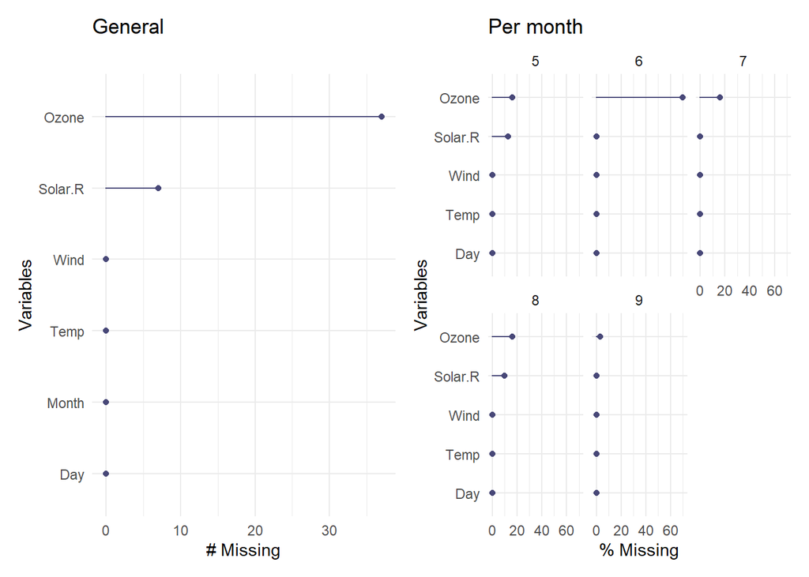

```r
library(patchwork)
p1 <- gg_miss_var(airquality)+ggtitle("General")
p2 <- gg_miss_var(airquality, facet = Month, show_pct = T) +
        ggtitle("Per month")
p1+p2
```

Finalmente, la función `vis_miss()` puede resultar de mucha ayuda para visualizar la localización de los valores faltantes y para intuir la existencia de algún patrón en los mismos que pudiera ser de utilidad para su análisis. Por ejemplo, se observa cómo la densidad de valores faltantes de `Ozone` va disminuyendo conforme avanza el tiempo.

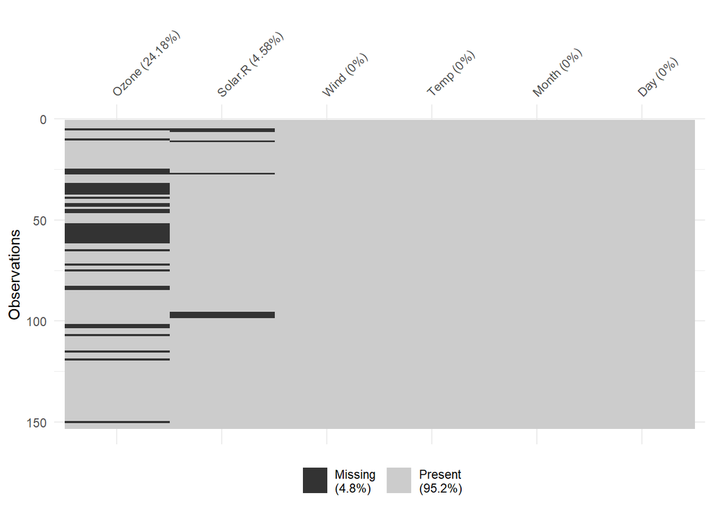

```r
vis_miss(airquality)
```

En el caso de que necesitáramos un conjunto de datos sin valores faltantes, podríamos eliminar las variables u observaciones con mayor cantidad de estos valores. Una variable que tenga más de un 60-80% de valores faltantes es poco recuperable, y no está aconsejado hacerlo. Una manera sencilla de quedarnos únicamente con las observaciones completas es mediante la función `complete.cases()`, que devuelve un vector lógico según la fila entera esté o no completa.

```r
airquality <- airquality[complete.cases(airquality),]
```

## Imputación

Aunque hay muchos métodos para hacer imputación de datos, en este libro se presenta la metodología *Multivariate Imputation by Chained Equations* (MICE), pues cuenta con un gran soporte en la comunidad por su estabilidad. MICE realiza múltiples imputaciones y nos permite escoger la que queramos. Hay gran cantidad de métodos que se pueden utilizar en función del tipo de dato que queramos imputar u otras necesidades.

Para generar el objeto de la imputación utilizamos la siguiente línea de código. `m` indicará la cantidad de veces que se hará la imputación, mientras que `meth` el método que se utilizará. El método utilizado es *predicitive mean matching* (`pmm`), y resulta de los más polivalentes, pues se puede aplicar a cualquier tipo de variable. Consiste en rellenar los valores faltantes con otros valores ya presentes en el conjunto de datos. De esta manera se reduce mucho el sesgo y la probabilidad de tener valores anómalos. Finalmente, marcar la `seed` nos permitirá obtener resultados reproducibles.

```r
library(mice)
impData <- mice(airquality, m = 5, meth = "pmm", seed = 13)
```

```
##
##   1   1
##   1   2
##   1   3
##   1   4
##   1   5
##   2   1
##   2   2
##   2   3
##   2   4
##   2   5
##   3   1
##   3   2
##   3   3
##   3   4
##   3   5
##   4   1
##   4   2
##   4   3
##   4   4
##   4   5
##   5   1
##   5   2
##   5   3
##   5   4
##   5   5
```

Una vez realizada la imputación, hay que escoger una de las `m` imputaciones. Para ello, vamos a utilizar el siguiente código, que mostrará la distribución de las variables originales y de las imputadas, seleccionando aquella imputación cuya distribución se asemeje más a la original.

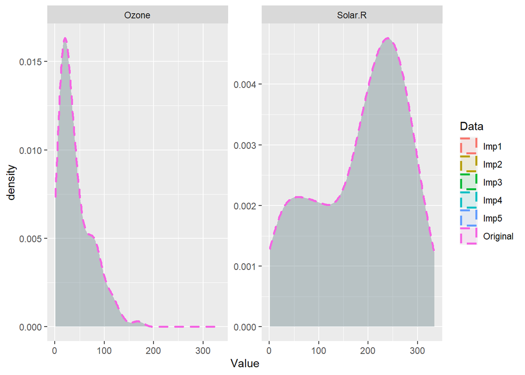

```r
plotData <- data.frame(Ozone = airquality$Ozone, Solar.R = airquality$Solar.R, Data = "Original")%>%
  tidyr::gather(key = "Variable", value = "Value", -Data)

m = 5
for (i in 1:m){
    temp = complete(impData,i)%>%select(Ozone, Solar.R)%>%
            mutate(Data = paste0("Imp", i))%>%
            tidyr::gather(key = "Variable", value = "Value", -Data)
    plotData = rbind(plotData, temp)
}

ggplot(plotData, aes(x = Value, col = Data, fill = Data))+
    geom_density(lwd = 1, alpha = 0.1, linetype = 8)+
    facet_wrap(Variable~., scales = "free_y")
```

```r
airqualityImp <- complete(impData, 3)
```

Con esto, ya tendríamos un conjunto de datos con todos sus valores completos.